# The Virtual Dutch Flashcards in R.

A Shiny application supporting words and verbs declination memorization.

Jacek Pardyak

2019-03-23

# Introduction

When I started learning Dutch, I couldn’t find an R-project to support my vocabulary memorization. So I started it myself.

What’s absurd, my goal is that I won’t need them in the near future.

Maybe someone else **vindt het leuk** or is willing participate in development.

# The data

There are two data sets:

1. List of Dutch words with English translation,

Vocabulary loosely covers material from this Handbook and is stored in *JSON* files. The list is continuously expanded with words and expressions that I find interesting.

[De opmaat, Naar NT2-niveau A2, Maud Beersmans, Wim Tersteeg](https://www.nt2.nl/en/100-37_De-opmaat)

[figure not shown]

Source: www.nt2.nl

2. List of irregular Dutch verbs with conjugated forms.

The list is a compilation of above mentioned handbook and this book

[Niderlandzki, Gramatyka z ćwiczeniami, Katarzyna Wiercińska](https://www.jezykiobce.pl/niderlandzki/1429-niderlandzki-gramatyka-z-cwiczeniami-9788377887462.html)

[figure not shown]

Source: www.jezykiobce.pl

I have chosen *JSON* file format in favour of *CSV* because one word can have more then one translation (or conjugated form) or can appear in several *Themas* with a different meaning. *List* data structure is very natural to store that kind of data.

The first dataset is a *data frame* with *lists*, the second is *data frame* of nested *data frames*.

The structure of *woordenlijst.json* is as follows:

```
## [
##   {
##     "TH": [0],
##     "NL": ["hoeven"],
##     "EN": ["to need"],
##     "PL": [""],
##     "ST": "FALSE",
##     "AD": "",
##     "EX": "Godzijdank hoef ik geen Pools te leren."
##   },
##   {
##     "TH": [0],
##     "NL": ["upload"],
##     "EN": ["to upload"],
##     "PL": [""],
##     "ST": "TRUE",
##     "AD": "",
##     "EX": "Ik heb de foto op Facebook geüpload."
##   },
##   {
##     "TH": [0],
##     "NL": ["koe"],
##     "EN": ["cow"],
##     "PL": ["krowa"],
##     "ST": "TRUE",
##     "AD": "de; -ien",
##     "EX": "Er zijn veel koeien in Nederland."
##   }
## ]
```

```
## [
##   {
##     "INF": "bakken",
##     "OTT": {
##       "SIN": {
##         "PE1": ["bak"],
##         "PE2": ["bakt"],
##         "PE3": "bakt"
##       },
##       "PLU": {
##         "PE1": "bakken",
##         "PE2": "bakken",
##         "PE3": "bakken"
##       },
##       "EXA": ""
##     },
##     "OVT": {
##       "SIN": {
##         "PE1": ["bakte"],
##         "PE2": ["bakte"],
##         "PE3": ["bakte"]
##       },
##       "PLU": {
##         "PE1": ["bakten"],
##         "PE2": ["bakten"],
##         "PE3": ["bakten"]
##       },
##       "EXA": ""
##     },
##     "VTT": {
##       "SIN": {
##         "PE1": ["heb gebakken"],
##         "PE2": ["hebt gebakken"],
##         "PE3": ["heeft gebakken"]
##       },
##       "PLU": {
##         "PE1": ["hebben gebakken"],
##         "PE2": ["hebben gebakken"],
##         "PE3": ["hebben gebakken"]
##       },
##       "EXA": ["Heb je het taart gebakken?"]
##     }
##   }
## ]
```

# The script

Script of my Shiny application is stored in two files available from this Repository:

https://github.com/JacekPardyak/FC

1. *ui.R*
2. *server.R*

This is the header of *ui.R* file:

```
##  [1] "library(shiny)"
##  [2] "library(shinydashboard)"
##  [3] "library(jsonlite)"
##  [4] "library(DT)"
##  [5] "sidebar <- dashboardSidebar(sidebarMenu("
##  [6] "  menuItem(\"Woorden\", tabName = \"woorden\", icon = icon(\"dashboard\")),"
##  [7] "  menuItem(\"Werkwoorden\", tabName = \"werkwoorden\", icon = icon(\"th\"))"
##  [8] "))"
##  [9] ""
## [10] "body <- dashboardBody(tabItems("
```

And the header of *server.R* file:

```
##  [1] "words <- fromJSON(txt = \"./data/woordenlijst.json\")"
##  [2] "verbs <- fromJSON(txt = \"./data/werkwoorden.json\")"
##  [3] ""
##  [4] "function(input, output, session) { "
##  [5] "  # INF - infinitief: werken, lezen"
##  [6] "  # OTT - onvoltooid tegenwoordige tijd: ik werk, ik lees"
##  [7] "  # OVT - onvoltooid verleden tijd: ik werkte, ik las"
##  [8] "  # VTT - voltooid tegenwoordige tijd: ik heb gewerkt, ik heb gelezen"
##  [9] "  #voltooid verleden tijd (vvt): ik had gewerkt, ik had gelezen"
## [10] "  #onvoltooid tegenwoordige toekomende tijd (ottt): ik zal werken, ik zal lezen"
```

Shortly about the *R* libraries:

- shiny is a general framework for building web applications,

  https://shiny.rstudio.com/
- shinydashboard turns Shiny applications into cool dashboards,

  https://rstudio.github.io/shinydashboard/
- jsonlite is used to process *JSON* files,

  https://cran.r-project.org/web/packages/jsonlite/
- dt is used to edit table directly in the dashboard.

  https://rstudio.github.io/DT/

# The application

As of 2019-03-23 my application supports:

1. Memorization of the Dutch words,

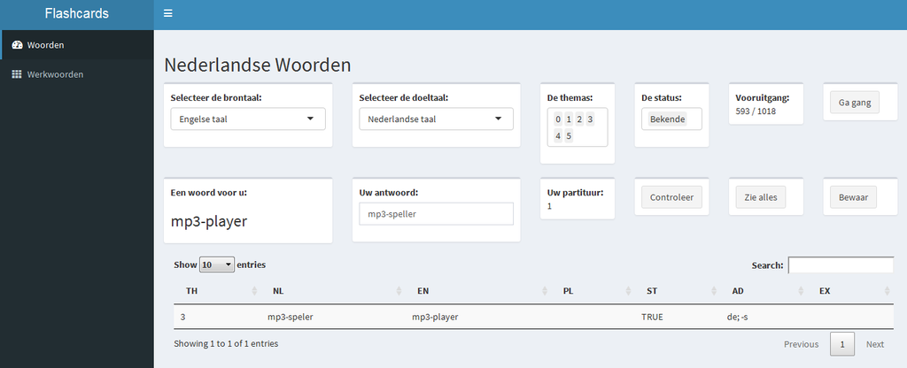

2. Learning forms of irregular Dutch verbs.

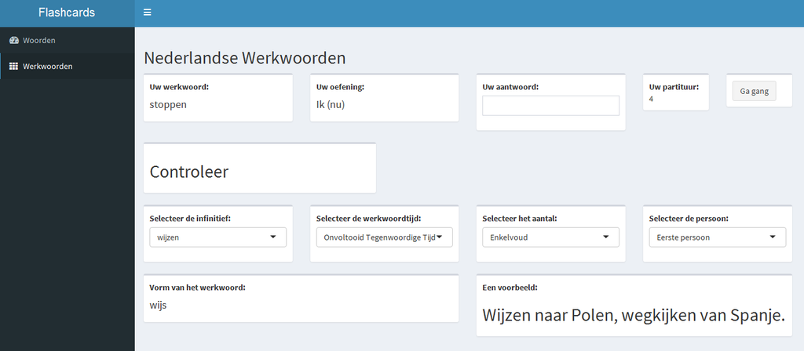

The usage is straightforward.

# Further work

Further I can:

- apply Leitner System,

  https://en.wikipedia.org/wiki/Leitner_system
- add more languages (Polish or Russian),
- expand the list with words and expressions I want to learn,
- add material I want to learn in the next level of my journey with Dutch language.